# Interesting

Mat Medina, Jaden Wang, Seung Lee

3/9/2022

### Proposal

This project aims to look into the data of how the united states economy has changed throughout the years in an attempt to glimmer an insightful perspective on how it is that the federal government has tried and/or managed to maintain the functions of our society, if we’ve suffered or benefitted from their choices, and the direction that our economy is facing as we progress forward.

### Summary

Some important variables we’ve thought to look into are:

- The max inflation within the years 1960 to 2015 is 12.4333333 in the year 1980.
- The min inflation within the years 1960 to 2015 is 0.9583333 in the year 2010
- The max federal rate within the years 1960 to 2015 is 16.3783333 in the year 1981
- The min federal rate within the years 1960 to 2015 is 0.0891667 in the year 2014
- The max unemployment rate the years within 1960 to 2015 is 9.7083333 in the year 1982
- The min unemployment rate the years within 1960 to 2015 is 3.4916667 in the year 1969

### Table

```
## # A tibble: 56 x 5
##     Year Federal_rate_YearlyMe~ Inflation_Yearl~ Unemployment_Ye~ CPI_YearlyMean
##    <dbl>                  <dbl>            <dbl>            <dbl>          <dbl>
##  1  1960                   3.22             1.52             5.54           29.6
##  2  1961                   1.96             1.12             6.69           29.9
##  3  1962                   2.71             1.38             5.57           30.2
##  4  1963                   3.18             1.28             5.64           30.6
##  5  1964                   3.50             1.5              5.16           31.0
##  6  1965                   4.07             1.44             4.51           31.5
##  7  1966                   5.11             2.42             3.79           32.5
##  8  1967                   4.22             3.48             3.84           33.4
##  9  1968                   5.66             4.63             3.56           34.8
## 10  1969                   8.20             5.81             3.49           36.7
## # ... with 46 more rows
```

We have here a table of all the relevant information we’ve found are relevant, from the various datasets we’ve found, mainly, from [Federal Reserve Interest Rates, 1954-Present](https://www.kaggle.com/federalreserve/interest-rates) and [U.S. Inflation Data](https://www.kaggle.com/varpit94/us-inflation-data-updated-till-may-2021) while supported by [Historical Federal Interest Rates-Daily](https://www.kaggle.com/dennisholeski/historical-fed-funds) and [US Consumer Price Index and Inflation (CPI)](https://www.kaggle.com/tunguz/us-consumer-price-index-and-inflation-cpi). The dataset itself contains the yearly averages of the Federal Rate, Inflation Rate, Unemployment Rate, and the CPI Rate

### CPI and Federal Rate Trends over time scatterplot

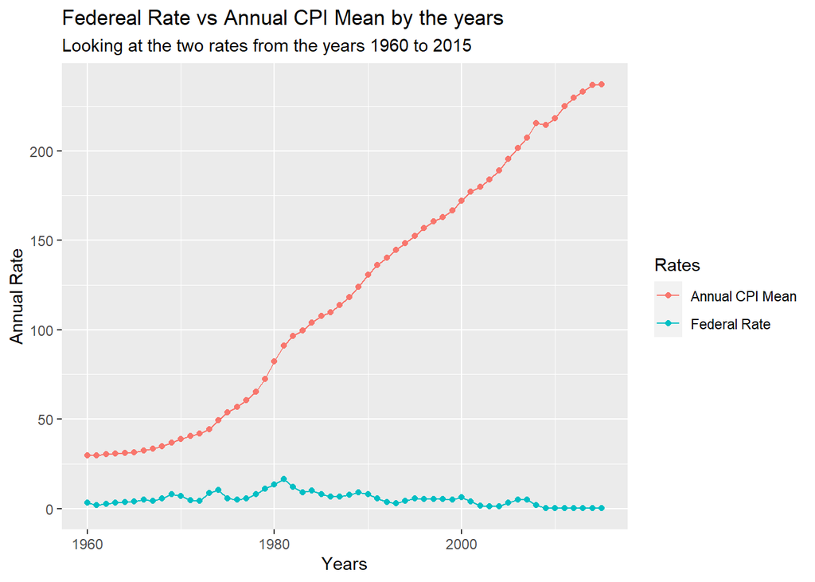

This chart shows the Trends over time of both the CPI and the Federal Rate, we can see here that the Annual CPI Mean is vastly increasing over the years while the Federal Rate is more or less maintaining a consistent raise and fall with it slightly descending. From the CPI, it tells us that the average change in price is steadily rising over the years increasing the pricing of the general products meanwhile the low Federal Rate tells us that banks are willing and are lending out lots of money to consumers as interest rates are lowered. Now while this might allude to a healthy economy, the high rise of CPI means that the general products are sold way at a more expensive rate which puts a lot of people at a disadvantage if they can’t utilize being able to effectively borrow and or pay back money from banks.

### Inflation Unemployment comparison line chart

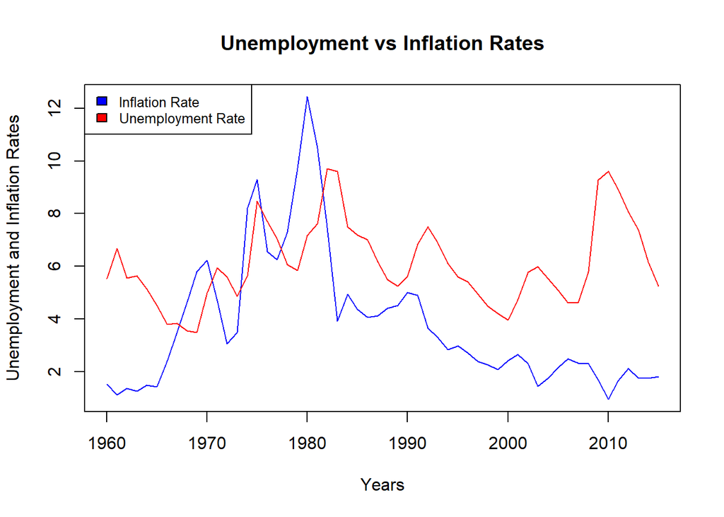

Here we see how Inflation and Unemployment charted, Inflation steadily rises a substantial amount during the early to middle ranges but has since slowly descended, meanwhile unemployment goes through a wild patterns of up and downs which seems to have a slight upward momentum. A low inflation rate with a much higher unemployment rate could be reflective of a healthy economy with a cautionary note of a substantial amount of people having a tougher time getting jobs.

### CPI and Inflation Bar Chart

[figure not shown]